# Plotting nestedLogit models

Michael Friendly and John Fox

2023-05-12

Load the packages we’ll use here:

```r
library(nestedLogit)    # Nested Dichotomy Logistic Regression Models
library(knitr)          # A General-Purpose Package for Dynamic Report Generation in R
library(dplyr)          # A Grammar of Data Manipulation
library(tidyr)          # Tidy Messy Data
library(ggplot2)        # Create Elegant Data Visualisations Using the Grammar of Graphics
library(geomtextpath)   # Curved Text in 'ggplot2'
```

The main vignette illustrated the basic plot method, `plot.nestedLogit()` in the package. However, to explain plotting nested-dichotomies models works, and for better control of the details, it is useful to describe how graphs can be constructed directly directly. We’ll use the same example of women’s labor force participation, using the original dichotomies:

```r
data(Womenlf, package = "carData")
Womenlf$partic <- with(Womenlf,
                       factor(partic, levels = c("not.work", "parttime", "fulltime")))

wlf.nested <- nestedLogit(partic ~ hincome + children,
                          dichotomies = logits(work=dichotomy("not.work", working=c("parttime", "fulltime")),
                                               full=dichotomy("parttime", "fulltime")),
                          data=Womenlf)
```

## Fitted probabilities

To draw a plot, it is sufficient to calculate predicted probabilities over a grid of values of the predictor variables. Here, we select a range of 0 - 45 in steps of 5, combined with the two values of `children`.

```r
new <- expand.grid(hincome=seq(0, 45, by = 5),
                   children=c("absent", "present"))

pred.nested <- predict(wlf.nested, newdata = new)
plotdata <- cbind(new, pred.nested)
head(plotdata)
```

```
#>   hincome children not.work parttime fulltime
#> 1       0   absent   0.2082  0.02372   0.7681
#> 2       5   absent   0.2452  0.03785   0.7169
#> 3      10   absent   0.2864  0.05907   0.6545
#> 4      15   absent   0.3315  0.08936   0.5791
#> 5      20   absent   0.3800  0.12944   0.4906
#> 6      25   absent   0.4309  0.17691   0.3922
```

### Using `matplot()`

Because the fitted values are in multiple columns, it is easiest to plot these using `matplot()`. We could plot these all in a single (messy) figure, but it is clearer to show separate panels for children `absent` and `present`.

To do this, the `plotdata` data set is subset within a loop over the values of `children` and each subset is plotted by `matplot`. It is only necessary to include the legend in one panel. The plots are combined into a single figure using `par(mfrow())`.

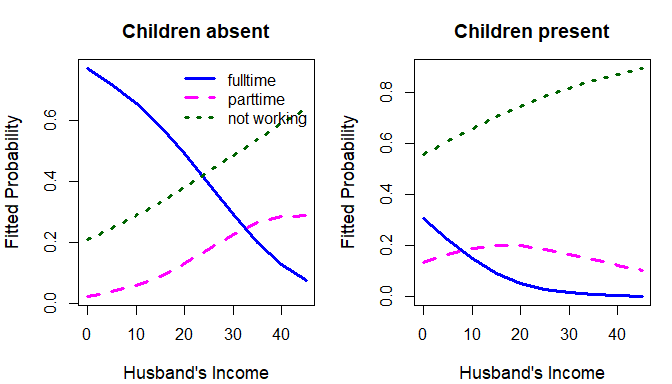

**matplot**: Predicted probabilities of working at all or working part time or full time

```r
op <- par(mfrow=c(1,2), mar=c(4,4,3,1)+.1)
cols=c("blue", "magenta", "darkgreen")
for ( kids in c("absent", "present") ) {
  data <- subset(plotdata, children==kids)
  matplot(data[, "hincome"], data[, 5:3],
          type = "l", lwd=3, lty = 1:3, col = cols,
          xlab="Husband's Income",
          ylab='Fitted Probability',
          main = paste("Children", kids),
          cex.lab = 1.1)
  if (kids=="absent") {
    legend("topright", lty=1:3, lwd=3, col=cols, bty = "n",
           legend=c("fulltime", "parttime", "not working"))
  }
}
```

```r
par(op)
```

### Using `ggplot()`

More control, and perhaps a more aesthetically pleasing figure can be produced using `ggplot` (Wickham et al., 2023). However, `ggplot` wants the data in long format. That makes it easy to plot probability against one predictor and use `color` to distinguish the levels of `partic` and facet the plot by `children`. (The result of `tidyr::pivot_longer()` doesn’t recognize an ordered nature of `"Working"`, so this is done in a separate step.)

```r
plotlong <- plotdata |>
  tidyr::pivot_longer(fulltime : not.work,
                      names_to = "Working",
                      values_to = "Probability") |>
  mutate(Working = ordered(Working,
                           levels = c("not.work", "parttime", "fulltime")) )

head(plotlong)
```

```
#> # A tibble: 6 x 4
#>   hincome children Working  Probability
#>     <dbl> <fct>    <ord>          <dbl>
#> 1       0 absent   fulltime      0.768
#> 2       0 absent   parttime      0.0237
#> 3       0 absent   not.work      0.208
#> 4       5 absent   fulltime      0.717
#> 5       5 absent   parttime      0.0378
#> 6       5 absent   not.work      0.245
```

Then, one call to `ggplot` produces both panels. To sort the levels of `Working` appropriately, we made this an ordered factor in the step above, but assign the colors with a discrete scale.

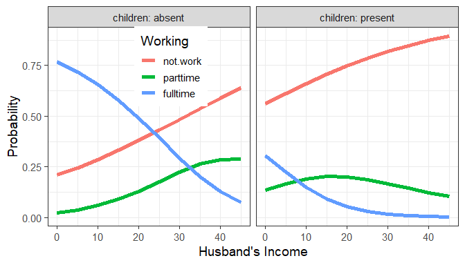

**ggplot**: Predicted probabilities of working at all or working part time or full time

```r
gg <- ggplot(plotlong,
             aes(x=hincome, y=Probability, color=Working)) +
  geom_line(linewidth = 2) +
  scale_color_discrete() +
  labs(x="Husband's Income", y= "Probability") +
  facet_wrap(~ children, labeller = label_both) +
  theme_bw(base_size = 14) +
  theme(legend.position = c(.3, .8))
gg
```

### Direct labels

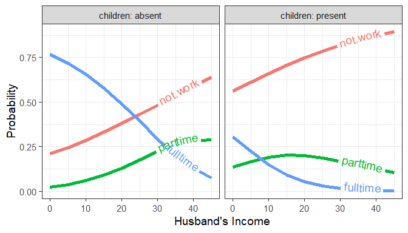

**geomtextpath**: Predicted probabilities, with labels on the curves

```r
ggplot(plotlong,
       aes(x=hincome, y=Probability, color=Working)) +
  geom_textline(aes(label = Working),
                linewidth = 2, size = 5,
                hjust = 0.9, vjust = 0.2) +
  scale_color_discrete() +
  labs(x = "Husband's Income", y = "Probability") +
  facet_wrap(~ children, labeller = label_both) +
  theme_bw(base_size = 14) +
  theme(legend.position = "none")
```

## Plotting fitted log odds

It is sometimes easier to interpret logistic regression models by plotting the linear predictors on the **log odds** scale, because these appear as straight lines. That is, from the estimated coefficients in the model, the predicted log odds of `work` and `full` are given by

$$L_1 =\log\left[ \frac { \widehat{P( \operatorname{work} =
\operatorname{1} )} }{ 1 - \widehat{P( \operatorname{work} =
\operatorname{1} )} } \right] = 1.34 - 0.04(\operatorname{hincome}) -
1.58(\operatorname{children}_{\operatorname{present}})$$

$$L_2 =\log\left[ \frac { \widehat{P( \operatorname{full} =
\operatorname{1})} }{ 1 - \widehat{P( \operatorname{full} =
\operatorname{1})} } \right] = 3.48 - 0.11(\operatorname{hincome}) -
2.65(\operatorname{children}_{\operatorname{present}})$$
Here, $\operatorname{children}_{\operatorname{present}}$ is either 0 or 1, so this amounts to a shift in the intercept when children are present.

These values can be calculated by calling `predict.glm()` directly for the `models` component of `wlf.nested`, specifying `type = "link"`:

```r
pred.logits <- sapply(models(wlf.nested), predict, newdata=new, type = "link")
plotdatal <- cbind(new, pred.logits)
head(plotdatal)
```

```
#>   hincome children   work   full
#> 1       0   absent 1.3358 3.4778
#> 2       5   absent 1.1243 2.9414
#> 3      10   absent 0.9127 2.4051
#> 4      15   absent 0.7012 1.8688
#> 5      20   absent 0.4897 1.3324
#> 6      25   absent 0.2781 0.7961
```

Then we plot these more or less as before:

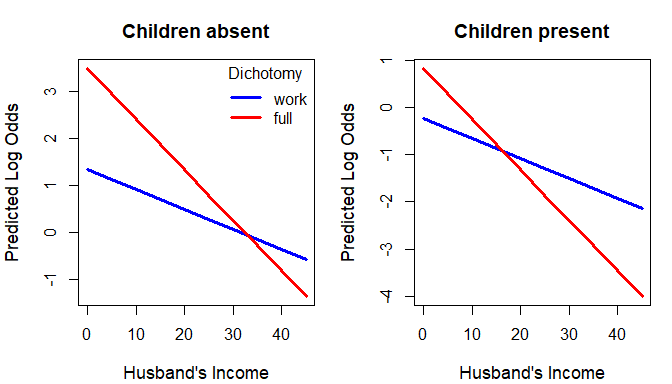

**log odds**: Predicted logits of the `work` and `full` dichotomies, by `children`

```r
cols <- c("blue", "red")

op <- par(mfrow=c(1,2), mar=c(4,4,3,1)+.1)
for ( kids in c("absent", "present") ) {
  data <- subset(plotdatal, children==kids)
  matplot(data[, "hincome"], data[, 3:4],
          type = "l", lwd=3, lty = 1, col = cols,
          xlab="Husband's Income",
          ylab='Predicted Log Odds',
          main = paste("Children", kids),
          cex.lab = 1.1)
  if (kids=="absent") {
    legend("topright", lty=1, lwd=3, col=cols, bty = "n",
           title = "Dichotomy",
           legend=c("work", "full"))
  }
}
```

```r
par(op)
```

Finally, we can use `ggplot` as before to plot the fitted logits, first transforming the long format.

```r
plotlongl <- plotdatal |>
  tidyr::pivot_longer(work : full,
                      names_to = "Dichotomy",
                      values_to = "logit") |>
  mutate(Dichotomy = ordered(Dichotomy,
                         levels = c("work", "full")) )
```

Doing this gives the flexibility that we can facet the plot either by `children` (as before) or `Dichotomy`. The latter nicely shows that the additive model has equal slopes for husband’s income within both panels: increasing husband’s income decreases the log odds of working, but at a faster rate for the `full` dichotomy. Having young children decreases the log odds of working either at all or working fulltime as compared to parttime.

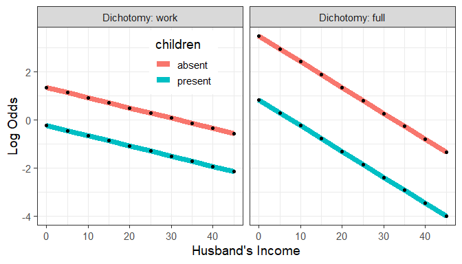

**log odds**: Predicted logits of the `work` and `full` dichotomies, by `Dichotomy`

```r
ggplot(plotlongl,
       aes(x=hincome, y=logit, color=children)) +
  geom_line(linewidth = 3) +
  geom_point(size = 1.5, shape = 16, color = "black") +
  scale_color_discrete() +
  labs(x="Husband's Income", y= "Log Odds") +
  facet_wrap(~ Dichotomy, labeller = label_both) +
  theme_bw(base_size = 14) +
  theme(legend.position = c(.35, .82))
```

## References

Wickham, H., Chang, W., Henry, L., Pedersen, T. L., Takahashi, K., Wilke, C., … Dunnington, D. (2023). *ggplot2: Create elegant data visualisations using the grammar of graphics*. Retrieved from https://CRAN.R-project.org/package=ggplot2